# Biostatistics HW12: Stan and Time Series

Sophia Frantz

1/24/2020

# Introduction: Lotka-Volterra Equations and the Dataset

To explain the dynamics of predator and prey interactions in an ecosystem, the Lotka-Volterra equations were developed. These equations are useful to ecologists in helping to explain how the numbers of prey and predators in a system are dependent on each other. The equations are based on some key assumptions:  
- If left unchecked by predators, the prey population intrinsically increases;  
- Without adequate amounts of prey, the predator populattion intrinsically decreases;  
- More prey leads to more predators, but  
- More predators leads to less prey.

These assumptions produce a cycle of increasing and decreasing prey and predator population sizes. This dynamic is illustrated in Fig. 1 below. This figure plots a dataset that records the total number of mice and foxes on an island each year for 100 years, from 1750-1850. (The data is fake, but it emulates the real data of lynx/rabbit dynamics that inspired the Lotka-Volterra equations.)

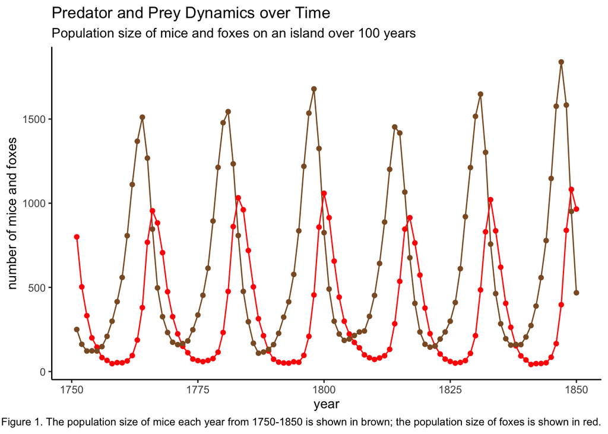

# The Model

In addition to the current population of mice (*M*) and foxes (*F*), the Lotka-Volterra equations use four other parameters to predict the next year’s population sizes (*M*t+1 and *F*t+1). The Lotka-Volterra equations that I use in this report and descriptions of their parameters are shown below:

*M*t+1 ~ Poission(($\lambda$ + *r*t)*M*t)  
*F*t+1 ~ Poission($\rho$ *F*t + $\gamma$ (1-*r*t)*M*t)

- the rate of encountering each fox for each mouse ($\epsilon$)
- mouse fecundity, per capita ($\lambda$)
- survival probability until the next year for each fox ($\rho$)
- the rate of mice eaten to baby foxes produced ($\gamma$)

Additionally, the probability that a mouse escapes all foxes when the population size consists of *F* foxes (*r*) is given by an equation that includes the epsilon parameter: *r* = exp(- $\epsilon$ *F*)

Given these equations that show how the population sizes and ecological functions interact with each other, and given the actual numbers of mice and foxes over time, we can now use this information to estimate the parameters of the equations. Estimating the parameters allow us to better understand the population dynamics of this system. For example, we know the population size depends on the per-capita mouse fecundity ($\lambda$), but we can ask what is an estimate for mouse fecundity in this system, given the data and the model based on Lotka-Volterra equations?

To answer this question, I estimate $\lambda$ and the other 3 parameters using Bayesian inference.

# Inferring Parameters using Bayesian Inference in Stan

I used the record of population sizes for mice and foxes for each year (Fig. 1) and the model based on Lotka-Volterra equations (above) to infer the parameters that constitute the model. I also needed to decide how to restrict the paramaters to a suitable range and to choose a distribution to sample possible values of the parameters. This process is called choosing a prior because it relies on prior knowledge to restrict the values the parameters take so that the parameters can be esimated with all available information. I specified that the parameters representing probabilities, the probability of survival for foxes ($\rho$) and the per-fox encounter rate ($\epsilon$) should be drawn from a beta distribution. This distribution is often used for describing probabilities. I did not have any informed predictions about the shape of this distribution, so I set a uniform distribution which meant that any value chosen from the distribution was equally likely. If I had a better understanding of the system or information from a previous study, I could have used a more informative prior.

In contrast, I implemented more restrictions on the distribution for estimating per-capita mouse fecundity ($\lambda$). The average litter size of *mus musculus* is 6-8, and the average number of litters per year ranges from 5-10. This suggests that mouse fecundity can range widely between individual mice, but on average it seems likely that most individuals will have at least 1 offspring. Therefore, I sampled from a half-normal distribution (to restrict to positive values) with a mean of 1 and standard deviation of 10.

I also used a half-normal distribution to bound the conversion rate from mice eaten to baby foxes. I had no knowledge of a likely conversion rate except that it would likely be lower than 1 (foxes probably need to eat multiple mice to have enough energy to reproduce), so I set the mean to 0 and the standard deviation to 1.

# Posterior Sampling

I used the data and the model including these described priors to get samples from the posterior distributions of the 4 parameters. I performed the sampling with Markov Chain Monte Carlo (MCMC) in the program Stan. I used 3 Markov chains with 10,000 iterations in each one. The first 5,000 iterations were part of the warmup, so 5,000 total samples were drawn from each posterior distribution. Shown below are the trace plots of the 3 chains for each parameter. Because the chains overlap each other, this indicates the sampling process was similar among the 3 chains. This “mixing” is akin to replication of results and lends confidence to the estimates of the posterior samples. Furthermore, $\hat{R}$ measures distance between chains to quantify how well chains have mixed, with values close to 1 indicating better mixing. $\hat{R}$ = 1 for all parameters.

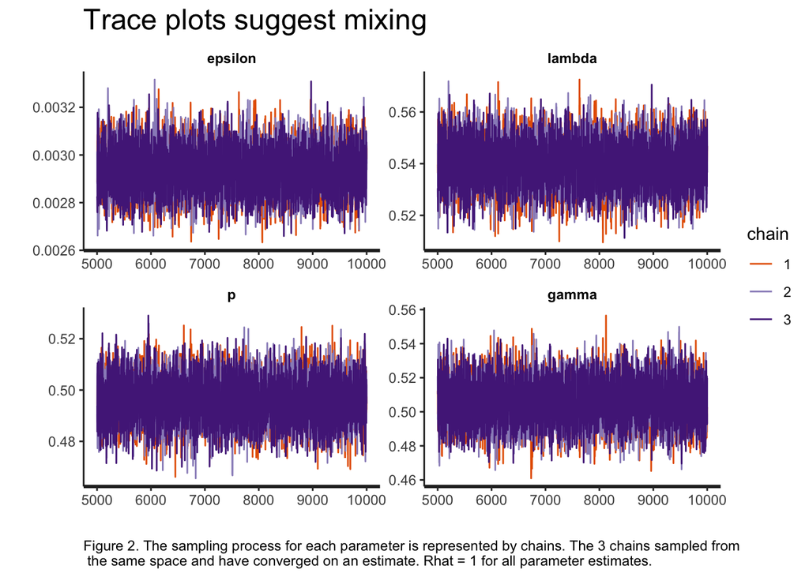

# Results: Estimated Parameters

Below, Figure 3 shows the posterior distributions of each parameter. To get a better sense of these distributions and their uncertainty, Figure 4 shows the posterior median, 75% credible region and 95% credible region for each parameter. To understand the ecological dynamics, it is useful to translate these parameters into biological terms: the low value of $\epsilon$ means that for each fox, a single mouse has a small probability of being eaten but when multiplied by *F* foxes, this probability increases. $\lambda$ = 0.54 means that for every 2 mice there is 1 surviving offspring per year. $\gamma$ = 0.51 means among the foxes that survive to reproduce, a baby fox is born for every 2 mice eaten. $\rho$ = 0.49 means that every fox has a 49% chance of surviving to the next year.

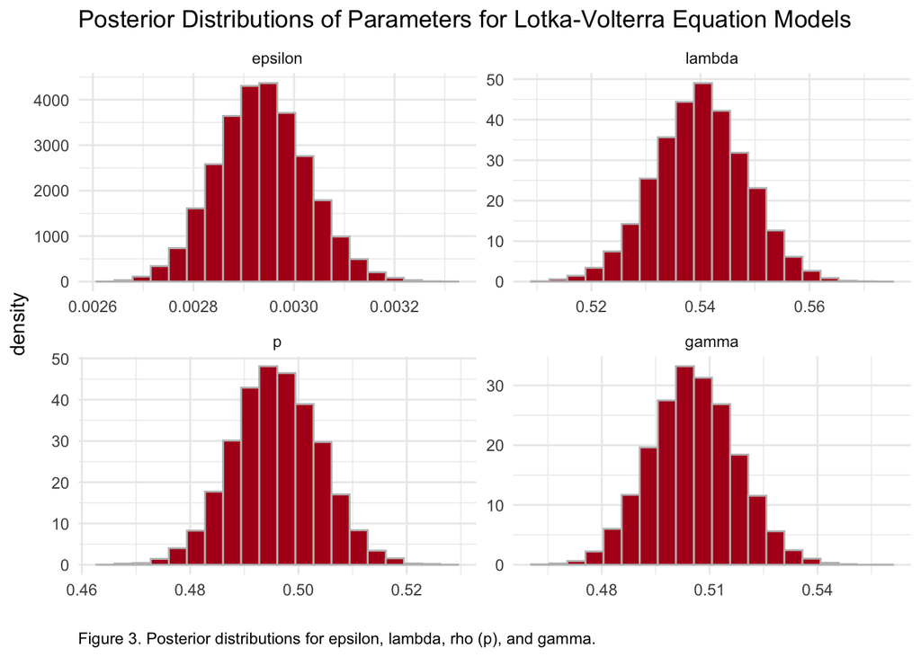

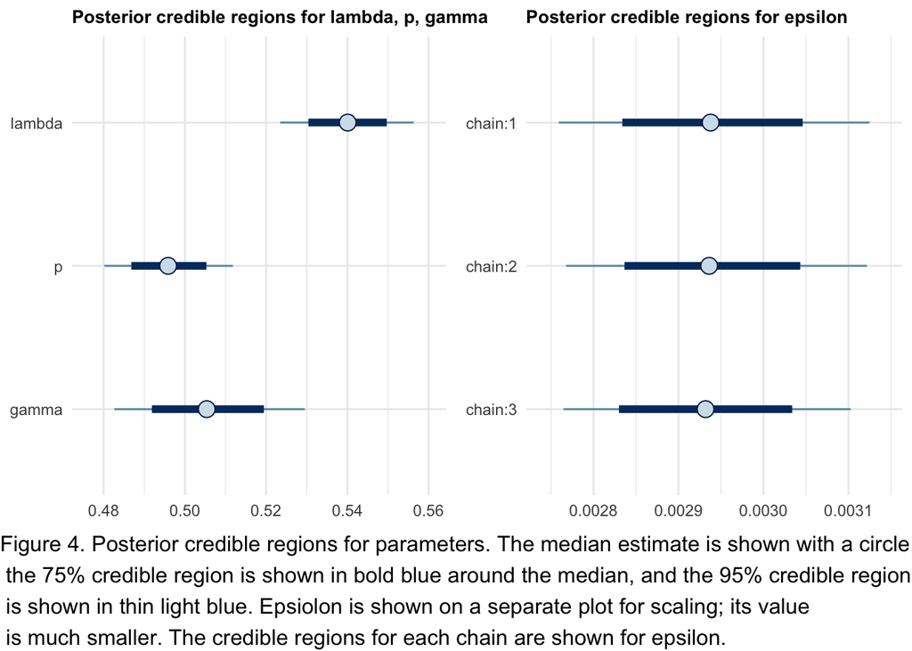

# Simulation of the Model with Parameters Derived from Stan:

These credible intervals (shown in Fig. 4) are quite narrow for all our parameters. Another way to find out if the parameters are doing agood job of describing the data is to simulate under the given parameters and compare this simulated data to the real data. I used the same model of Lotka-Volterra equations and the mean of the posterior distribution for each parameter:

*r* = exp(- $\epsilon$ *F*)  
*M*t+1 ~ Poission(($\lambda$ + *r*t)*M*t)  
*F*t+1 ~ Poission($\rho$ *F*t + $\gamma$ (1-*r*t)*M*t)

- $\epsilon$ = 0.0029
- $\lambda$ = 0.540
- $\gamma$ = 0.505
- $\rho$ = 0.495

The only time I used the real data was to set the initial population of mice and foxes to the population in the first year of the real data, 1750. The simulation predicted year 2 with the initial population sizes, the model, and the parameters with the given values. It predicted year 3 with its prediction from year 2, and so on for 100 years. The simulated data is plotted in Figure 5 below, showing the predicted population size of mice and foxes over time:

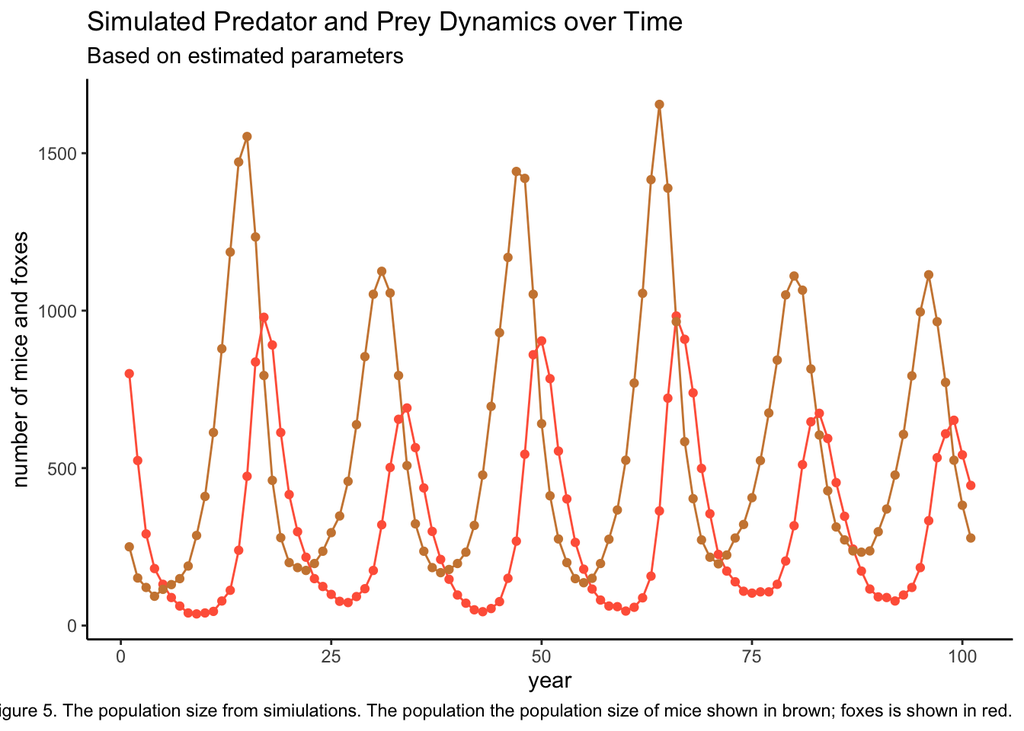

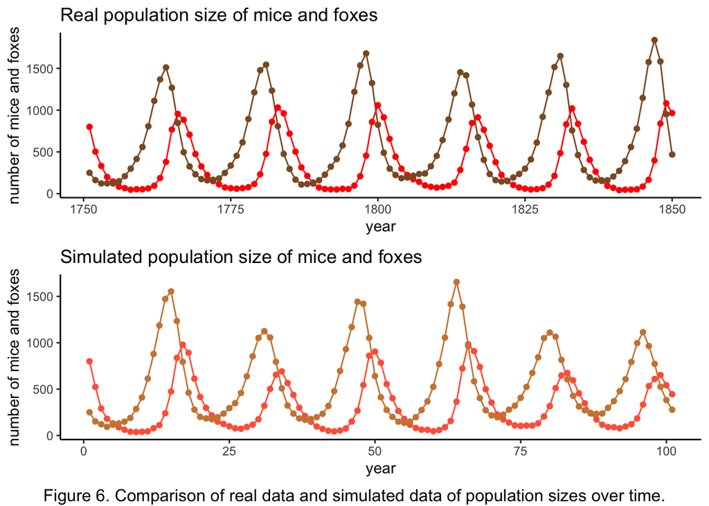

# Conclusions

The parameters chosen to describe the predator-prey dynamics based on Lotka-Volterra models seem to describe the data well, based on the narrow confidence intervals for the parameters and the results of the simulations. One reason we could estimate so well is that the Lotka-Volterra models do a very good job of describing these dynamics and that the Bayesian model was also implemented correctly. Of course, the data assumes that every fox and mouse was counted on the island. A more realistic scenario would involve estimates of population sizes, and we could incorporate this sampling noise into our model.